# Hasil Analisis

Hana Faiza Amalina

2024-04-27

# Data

```r
data=read_excel("C:\\Users\\hanfai\\skripsi\\semhas\\hasil\\data.xlsx", sheet = "datafix_2")
head(data)
```

```
## # A tibble: 6 × 19
##      ID KabKota      Long   Lat Tahun   TPT    UMK  TPAK    DR    KP   PPM   RLS
##   <dbl> <chr>       <dbl> <dbl> <dbl> <dbl>  <dbl> <dbl> <dbl> <dbl> <dbl> <dbl>
## 1     6 Kab Pandeg…  106. -6.75  2018  8.19 2.36e6  62.4  57.7   440  9.61  6.72
## 2     5 Kab Lebak    106. -6.56  2018  7.57 2.31e6  67.4  54.2   378  8.41  6.21
## 3     8 Kab Tanger…  106. -6.19  2018  9.63 3.56e6  63.0  45.0  3649  5.18  8.27
## 4     7 Kab Serang   106. -6.14  2018 12.6  3.54e6  61.8  51.0   866  4.3   7.18
## 5     3 Kota Tange…  107. -6.17  2018  7.39 3.58e6  63.0  37.8 14197  4.76 10.5
## 6     1 Kota Cileg…  106. -6.02  2018  9.21 3.62e6  63.0  44.2  2458  3.25  9.73
## # ℹ 7 more variables: EG <dbl>, AHH <dbl>, PPS <dbl>, PMA <dbl>,
## #   `TPT^1.5` <dbl>, `ln(TPT)` <dbl>, `exp(TPT)` <dbl>
```

# 1. Eksplorasi Data

```r
setwd("C:\\Users\\hanfai\\skripsi\\semhas\\hasil")
data.2018=data %>% filter(Tahun==2018)
data.2019=data %>% filter(Tahun==2019)
data.2020=data %>% filter(Tahun==2020)
data.2021=data %>% filter(Tahun==2021)
data.2022=data %>% filter(Tahun==2022)

data2=cbind(data.2018[,6:16],data.2019[,6:16],data.2020[,6:16],
            data.2021[,6:16],data.2022[,6:16])

#memberi nama kolom
nama=colnames(data.2020[,6:16])
nama2=c(paste0(nama,"_2018"),paste0(nama,"_2019"),paste0(nama,"_2020"),
        paste0(nama,"_2021"),paste0(nama,"_2022"))
colnames(data2)<-nama2
data2$ID=data$ID[1:35]
head(data2)
```

```
##   TPT_2018 UMK_2018 TPAK_2018 DR_2018 KP_2018 PPM_2018 RLS_2018 EG_2018
## 1     8.19  2363549     62.39   57.73     440     9.61     6.72    5.30
## 2     7.57  2312384     67.40   54.20     378     8.41     6.21    5.63
## 3     9.63  3555835     63.01   45.05    3649     5.18     8.27    5.80
## 4    12.63  3542714     61.77   51.03     866     4.30     7.18    5.29
## 5     7.39  3582077     63.01   37.84   14197     4.76    10.51    4.95
## 6     9.21  3622215     63.02   44.15    2458     3.25     9.73    6.11
##   AHH_2018 PPS_2018   PMA_2018 TPT_2019 UMK_2019 TPAK_2019 DR_2019 KP_2019
## 1    64.24    38.48   102.6484     8.67  2542539     60.88   57.24     441
## 2    66.79    39.17   426.6625     7.96  2498068     64.37   54.52     380
## 3    69.61    32.05 13954.3024     8.92  3841368     66.07   45.00    3756
## 4    64.22    38.78  3797.1463    10.58  3827193     63.30   50.96     870
## 5    71.45    29.73  3222.9582     7.14  3869717     64.95   37.72   14486
## 6    66.43    31.79 10778.2417     9.64  3913078     62.03   44.01    2491
##   PPM_2019 RLS_2019 EG_2019 AHH_2019 PPS_2019     PMA_2019 TPT_2020 UMK_2020
```

[output cut: 34 more lines]

```r
#import SHP
shp.banten.jabar=read_sf("SHP Banten Jabar Kabkot/banten jabar kabkot.shp")
gabung.banten.jabar=left_join(shp.banten.jabar,data2,by="ID")

nama=gabung.banten.jabar$KABUPATEN
nama2=as.data.frame(matrix(nama,36,1))
```

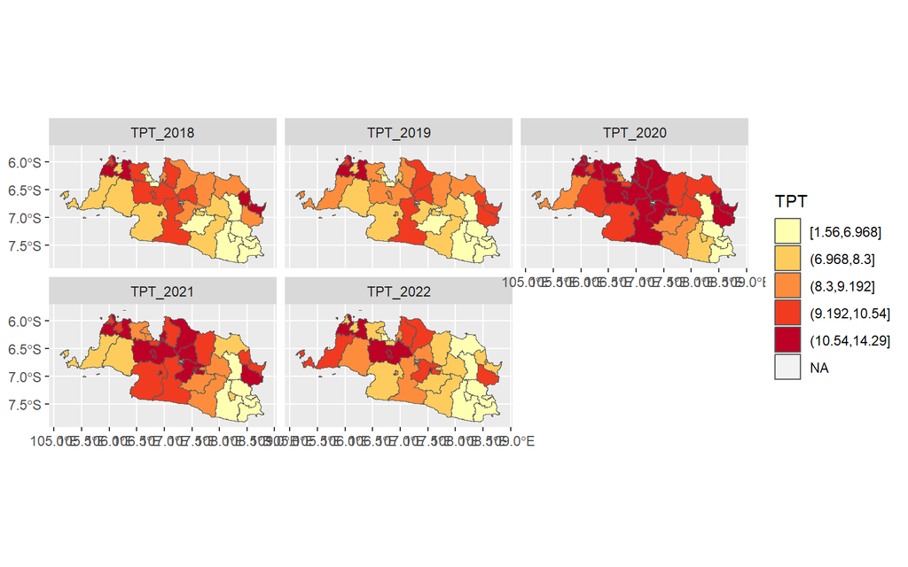

```r
# Peta tematik
varY <- gabung.banten.jabar %>%
  dplyr::select("TPT_2018","TPT_2019","TPT_2020","TPT_2021","TPT_2022", geometry) %>%
  tidyr::gather(VAR, TPT1, -geometry)%>%
  mutate(TPT = cut_number(TPT1, n = 5,dig.lab=5 ))

ggplot() +
  geom_sf(data = varY, aes(fill = TPT)) +
  facet_wrap(~VAR, ncol = 3) +
  scale_fill_brewer(type = "seq", palette = "YlOrRd")
```

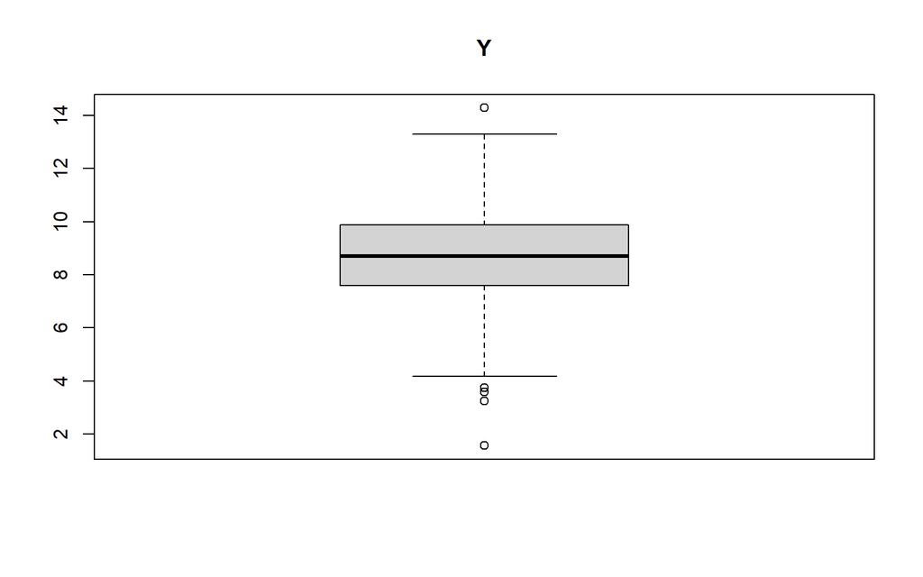

```r
# Boxplot masing-masing peubah
boxplot(data$TPT, main = "Y")
```

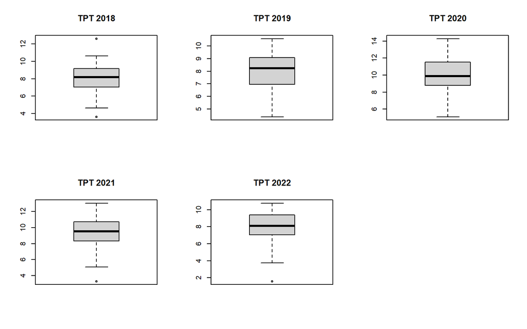

```r
par(mfrow = c(2,3))
boxplot(data2$TPT_2018, main = "TPT 2018")
boxplot(data2$TPT_2019, main = "TPT 2019")
boxplot(data2$TPT_2020, main = "TPT 2020")
boxplot(data2$TPT_2021, main = "TPT 2021")
boxplot(data2$TPT_2022, main = "TPT 2022")

par(mfrow = c(2,5))
```

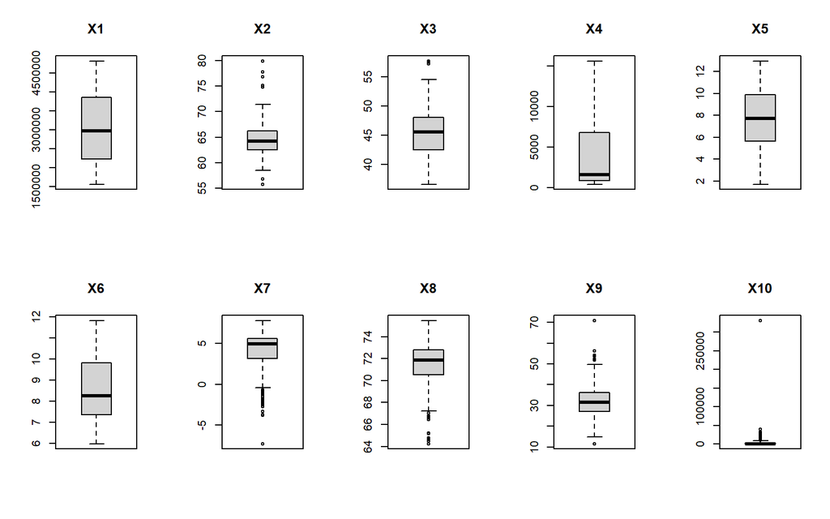

```r
boxplot(data$UMK, main = "X1")
boxplot(data$TPAK, main = "X2")
boxplot(data$DR, main = "X3")
boxplot(data$KP, main = "X4")
boxplot(data$PPM, main = "X5")
boxplot(data$RLS, main = "X6")
boxplot(data$EG, main = "X7")
boxplot(data$AHH, main = "X8")
boxplot(data$PPS, main = "X9")
boxplot(data$PMA, main = "X10")
```

# 2. Analisis Data Panel

```r
#scaling
data_scaled <- scale(data[,6:16])
datafix <- cbind(data[,1:5], data_scaled)
head(datafix)
```

```
##   ID        KabKota     Long     Lat Tahun        TPT        UMK       TPAK
## 1  6 Kab Pandeglang 105.6882 -6.7483  2018 -0.2113417 -0.7196106 -0.6767339
## 2  5      Kab Lebak 106.2522 -6.5644  2018 -0.4920783 -0.7740523  0.7761444
## 3  8  Kab Tangerang 106.4877 -6.1870  2018  0.4406919  0.5490302 -0.4969366
## 4  7     Kab Serang 106.0405 -6.1397  2018  1.7990951  0.5350690 -0.8565312
## 5  3 Kota Tangerang 106.6403 -6.1702  2018 -0.5735825  0.5769528 -0.4969366
## 6  1   Kota Cilegon 106.0558 -6.0187  2018  0.2505154  0.6196613 -0.4940366
##          DR         KP        PPM        RLS        EG         AHH         PPS
## 1  2.764894 -0.7694489  0.6686387 -1.2294142 0.5523355 -2.81221587  0.73279335
## 2  1.962015 -0.7829308  0.2434933 -1.5614922 0.6647056 -1.79970925  0.81862259
## 3 -0.119103 -0.0716494 -0.9008565 -0.2201575 0.7225932 -0.67999604 -0.06703566
## 4  1.241015 -0.6768149 -1.2126298 -0.9298929 0.5489304 -2.82015710  0.77011041
## 5 -1.758978  2.2220212 -1.0496574  1.2383813 0.4331551  0.05059697 -0.35562093
## 6 -0.323803 -0.3306333 -1.5846320  0.7304972 0.8281530 -1.94265136 -0.09937711
##           PMA
## 1 -0.19240810
## 2 -0.17974804
## 3  0.34881145
## 4 -0.04805462
## 5 -0.07048962
## 6  0.22471464
```

```r
#multikol
reg <- lm(TPT ~ UMK + TPAK + DR + KP + PPM + RLS + EG + AHH + PPS + PMA, data = datafix)
vif(reg)
```

```
##      UMK     TPAK       DR       KP      PPM      RLS       EG      AHH
## 2.412504 1.453140 2.774371 5.410427 2.779299 6.170559 1.077245 1.739744
##      PPS      PMA
## 1.170695 1.143865
```

Berdasarkan nilai VIF yang dihasilkan, seluruh peubah penjelas memiliki nilai `VIF < 10`. Oleh karena itu, tidak ada peubah penjelas yang diseleksi pada tahap ini.

```r
#MOdel Random (REM)
rem <- plm(TPT ~ UMK + TPAK + DR + KP + PPM + RLS + EG + AHH + PPS + PMA,
           data=datafix, model="random", index = c("ID","Tahun"))

#Model Fixed (FEM)
fem <- plm(TPT ~ UMK + TPAK + DR + KP + PPM + RLS + EG + AHH + PPS + PMA,
           data=datafix, model="within", index = c("ID","Tahun"))

#Model Gabungan (CEM)
cem <- plm(TPT ~ UMK + TPAK + DR + KP + PPM + RLS + EG + AHH + PPS + PMA,
           data=datafix,model="pooling",index = c("ID","Tahun"))
```

```r
#UJI PEMILIHAN MODEL
### uji chow ###
pFtest(fem,cem) #model FEM
```

```
##
##  F test for individual effects
##
## data:  TPT ~ UMK + TPAK + DR + KP + PPM + RLS + EG + AHH + PPS + PMA
## F = 10.563, df1 = 34, df2 = 130, p-value < 2.2e-16
## alternative hypothesis: significant effects
```

```r
### uji hausman ###
phtest(fem,rem) #model FEM
```

```
##
##  Hausman Test
##
## data:  TPT ~ UMK + TPAK + DR + KP + PPM + RLS + EG + AHH + PPS + PMA
## chisq = 27.349, df = 10, p-value = 0.002292
## alternative hypothesis: one model is inconsistent
```

Hasil uji Chow dan uji Hausman memberikan `p-value < 0.05` sehingga H0 ditolak. Artinya, ada cukup bukti untuk menyatakan bahwa model regresi panel yang terpilih adalah model dengan pengaruh tetap (FEM) pada taraf nyata 5%.

```r
plmtest(fem, effect = "twoways", type = "bp")
```

```
##
##  Lagrange Multiplier Test - two-ways effects (Breusch-Pagan)
##
## data:  TPT ~ UMK + TPAK + DR + KP + PPM + RLS + EG + AHH + PPS + PMA
## chisq = 98.504, df = 2, p-value < 2.2e-16
## alternative hypothesis: significant effects
```

```r
plmtest(fem, effect = "individual", type = "bp")
```

```
##
##  Lagrange Multiplier Test - (Breusch-Pagan)
##
## data:  TPT ~ UMK + TPAK + DR + KP + PPM + RLS + EG + AHH + PPS + PMA
## chisq = 98.406, df = 1, p-value < 2.2e-16
## alternative hypothesis: significant effects
```

```r
plmtest(fem, effect = "time", type = "bp")
```

```
##
##  Lagrange Multiplier Test - time effects (Breusch-Pagan)
##
## data:  TPT ~ UMK + TPAK + DR + KP + PPM + RLS + EG + AHH + PPS + PMA
## chisq = 0.09875, df = 1, p-value = 0.7533
## alternative hypothesis: significant effects
```

```r
summary(fem)
```

```
## Oneway (individual) effect Within Model
##
## Call:
## plm(formula = TPT ~ UMK + TPAK + DR + KP + PPM + RLS + EG + AHH +
##     PPS + PMA, data = datafix, model = "within", index = c("ID",
##     "Tahun"))
##
## Balanced Panel: n = 35, T = 5, N = 175
##
## Residuals:
##     Min.  1st Qu.   Median  3rd Qu.     Max.
## -0.88971 -0.21883 -0.03615  0.17291  0.82941
##
## Coefficients:
##       Estimate Std. Error t-value  Pr(>|t|)
## UMK   1.253342   0.260306  4.8149 4.027e-06 ***
## TPAK -0.160324   0.060090 -2.6681   0.00860 **
## DR    0.106270   0.070721  1.5027   0.13535
## KP   -0.190747   0.352681 -0.5408   0.58954
## PPM   0.026086   0.178985  0.1457   0.88435
## RLS  -1.103341   0.508532 -2.1697   0.03185 *
## EG   -0.287550   0.033790 -8.5100 3.644e-14 ***
## AHH  -0.800244   0.623879 -1.2827   0.20188
## PPS   0.034263   0.036266  0.9448   0.34653
## PMA  -0.052612   0.033665 -1.5628   0.12053
## ---
## Signif. codes:  0 '***' 0.001 '**' 0.01 '*' 0.05 '.' 0.1 ' ' 1
##
## Total Sum of Squares:    48.729
## Residual Sum of Squares: 16.75
## R-Squared:      0.65627
## Adj. R-Squared: 0.53993
## F-statistic: 24.8201 on 10 and 130 DF, p-value: < 2.22e-16
```

# 3. Menyusun Matriks Pembobot Spasial

```r
longlat=datafix[1:35,3:4]
longlat2=datafix[,3:4]
```

## Pembobot spasial untuk pemodelan

```r
#k-NN
knn <- knearneigh(longlat, k=3)
nb <- knn2nb(knn, sym = TRUE)
w_knn <- nb2listw(nb)

#invers
d <- dist(longlat, method = "euclidean", diag = T, upper = T)
w1 <- as.matrix(1/d)
diag(w1) <- 0
w_inv <- mat2listw(w1,style = "W")

#exponensial
w2 <- as.matrix(exp(-d))
diag(w2) <- 0
w_exp <- mat2listw(w2,style = "W")
```

## Pembobot spasial untuk pengujian

```r
#k-NN
knn2 <- knearneigh(longlat2, k=3)
nb2 <- knn2nb(knn2, sym = TRUE)
w_knn2 <- nb2listw(nb2)

#invers
d2 <- dist(longlat2, method = "euclidean", diag = T, upper = T)
w1.2 <- as.matrix(1/d2)
w1.2[which(!is.finite(w1.2))] <- 0
w_inv2 <- mat2listw(w1.2,style = "W")

#exponensial
w2.2 <- as.matrix(exp(-d2))
diag(w2.2) <- 0
w_exp2 <- mat2listw(w2.2,style = "W")
```

# 4. Autokorelasi Spasial

```r
moran_I_knn <- moran.test(datafix$TPT, listw = w_knn2)
moran_I_knn
```

```
##
##  Moran I test under randomisation
##
## data:  datafix$TPT
## weights: w_knn2
##
## Moran I statistic standard deviate = 11.617, p-value < 2.2e-16
## alternative hypothesis: greater
## sample estimates:
## Moran I statistic       Expectation          Variance
##       0.643068363      -0.005747126       0.003119151
```

```r
moran_I_inv <- moran.test(datafix$TPT, listw = w_inv2)
moran_I_inv
```

```
##
##  Moran I test under randomisation
##
## data:  datafix$TPT
## weights: w_inv2
##
## Moran I statistic standard deviate = 12.694, p-value < 2.2e-16
## alternative hypothesis: greater
## sample estimates:
## Moran I statistic       Expectation          Variance
##      1.014016e-01     -5.747126e-03      7.124685e-05
```

```r
moran_I_exp <- moran.test(datafix$TPT, listw = w_exp2)
moran_I_exp
```

```
##
##  Moran I test under randomisation
##
## data:  datafix$TPT
## weights: w_exp2
##
## Moran I statistic standard deviate = 22.139, p-value < 2.2e-16
## alternative hypothesis: greater
## sample estimates:
## Moran I statistic       Expectation          Variance
##      9.802947e-02     -5.747126e-03      2.197251e-05
```

Hasil pengujian autokorelasi spasial menggunakan indeks Moran dilakukan menggunakan ketiga pembobot spasial. Ketiga pembobot spasial tersebut memberikan hasil yang sama, yaitu `p-value < 0.05` sehingga H0 ditolak. Artinya, ada cukup bukti untuk menyatakan bahwa terdapat autokorelasi spasial dalam data pada taraf nyata 5%.

# 5. Keragaman Spasial

```r
coordinates(datafix) <- c("Long", "Lat")
bp_test <- bptest(fem, ~ coordinates(datafix))
bp_test
```

```
##
##  studentized Breusch-Pagan test
##
## data:  fem
## BP = 3.4912, df = 2, p-value = 0.1745
```

Hasil uji Breusch-Pagan memberikan `p-value = 0.1745` sehingga H0 tidak ditolak. Artinya, tidak ada cukup bukti untuk menyatakan bahwa terdapat keragaman antar lokasi. Dalam konteks penelitian ini, dapat dikatakan bahwa tingkat pengangguran terbuka Provinsi Banten dengan Provinsi Jawa Barat cukup berbeda, namun tingkat pengangguran terbuka antar kab/kota di masing-masing provinsi mungkin cukup mirip atau tidak berbeda secara signifikan.

# 6. Uji Pengganda Lagrange

```r
lm_test_knn <- lm.LMtests(reg, listw = w_knn2, test="all")
summary(lm_test_knn)
```

```
##  Lagrange multiplier diagnostics for spatial dependence
## data:
## model: lm(formula = TPT ~ UMK + TPAK + DR + KP + PPM + RLS + EG + AHH +
## PPS + PMA, data = datafix)
## weights: w_knn2
##
##        statistic parameter   p.value
## LMerr    86.7907         1 < 2.2e-16 ***
## LMlag    87.7144         1 < 2.2e-16 ***
## RLMerr    6.5328         1  0.010590 *
## RLMlag    7.4565         1  0.006321 **
## SARMA    94.2471         2 < 2.2e-16 ***
## ---
## Signif. codes:  0 '***' 0.001 '**' 0.01 '*' 0.05 '.' 0.1 ' ' 1
```

```r
lm_test_inv <- lm.LMtests(reg, listw = w_inv2, test="all")
summary(lm_test_inv)
```

```
##  Lagrange multiplier diagnostics for spatial dependence
## data:
## model: lm(formula = TPT ~ UMK + TPAK + DR + KP + PPM + RLS + EG + AHH +
## PPS + PMA, data = datafix)
## weights: w_inv2
##
##        statistic parameter p.value
## LMerr   0.118026         1  0.7312
## LMlag   0.502342         1  0.4785
## RLMerr  0.023869         1  0.8772
## RLMlag  0.408185         1  0.5229
## SARMA   0.526211         2  0.7687
```

```r
lm_test_exp <- lm.LMtests(reg, listw = w_exp2, test="all")
summary(lm_test_exp)
```

```
##  Lagrange multiplier diagnostics for spatial dependence
## data:
## model: lm(formula = TPT ~ UMK + TPAK + DR + KP + PPM + RLS + EG + AHH +
## PPS + PMA, data = datafix)
## weights: w_exp2
##
##        statistic parameter p.value
## LMerr   0.990839         1  0.3195
## LMlag   0.251442         1  0.6161
## RLMerr  0.790939         1  0.3738
## RLMlag  0.051542         1  0.8204
## SARMA   1.042381         2  0.5938
```

Dengan menggunakan ketiga pembobot spasial, hanya pembobot spasial k-NN yang memberikan hasil yang signifikan. Hasil uji pengganda Lagrange dengan pembobot spasial k-NN menunjukkan bahwa terdapat keragaman pada peubah penjelas dan pada galat. Oleh karena itu, model yang dibangun adalah spatial durbin model (SDM) dengan pembobot spasial k-NN.

# 7. Analisis Spasial Panel

## Spatial Durbin Model

```r
datafix <- cbind(data[,1:5], data_scaled)
sdm <- spml(TPT ~ UMK + TPAK + DR + KP + PPM + RLS + EG + AHH + PPS+ PMA, data = datafix, listw = w_knn,
            model = "within", effect = "individual", spatial.error = "b", spatial.lag = "b")
summary(sdm)
```

```
## Spatial panel fixed effects error model
##
##
## Call:
## spml(formula = TPT ~ UMK + TPAK + DR + KP + PPM + RLS + EG +
##     AHH + PPS + PMA, data = datafix, listw = w_knn, model = "within",
##     effect = "individual", spatial.error = "b", spatial.lag = "b")
##
## Residuals:
##       Min.    1st Qu.     Median    3rd Qu.       Max.
## -1.2978102 -0.3334952  0.0047353  0.3453672  1.3958641
##
## Spatial error parameter:
##     Estimate Std. Error t-value  Pr(>|t|)
## rho 0.604461   0.061449  9.8368 < 2.2e-16 ***
##
## Coefficients:
##        Estimate Std. Error t-value  Pr(>|t|)
## UMK   0.5444705  0.0703590  7.7385 1.006e-14 ***
## TPAK -0.4093740  0.0478275 -8.5594 < 2.2e-16 ***
## DR    0.1767209  0.0600148  2.9446  0.003234 **
## KP    0.5838667  0.0944661  6.1807 6.382e-10 ***
## PPM  -0.0033954  0.0850747 -0.0399  0.968164
## RLS  -0.7795158  0.1193865 -6.5293 6.606e-11 ***
## EG   -0.1964433  0.1093994 -1.7957  0.072550 .
## AHH   0.1567744  0.0631450  2.4828  0.013037 *
## PPS   0.0302269  0.0375336  0.8053  0.420629
## PMA   0.0238430  0.0375423  0.6351  0.525364
## ---
## Signif. codes:  0 '***' 0.001 '**' 0.01 '*' 0.05 '.' 0.1 ' ' 1
```

```r
rsquare <- 1-var(sdm$resid)/var(datafix$TPT)
rsquare
```

```
## [1] 0.7118852
```

```r
#Normalitas sisaan
err <- sdm$residuals
ks.test(err, "pnorm", mean = mean(err), sd = sd(err))
```

```
##
##  Asymptotic one-sample Kolmogorov-Smirnov test
##
## data:  err
## D = 0.03931, p-value = 0.9497
## alternative hypothesis: two-sided
```

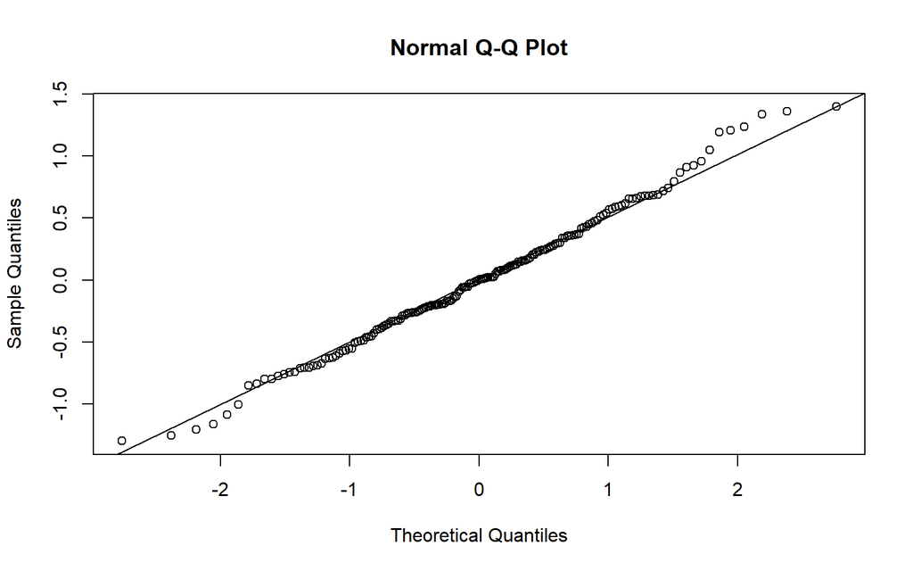

```r
qqnorm(err)
qqline(err)
```

```r
#Kehomogenan ragam
error <- abs(err)
datafix$error <- error
sdm.glejser <- lm(error ~ UMK + TPAK + DR + KP + PPM + RLS + EG + AHH + PPS + PMA, data = datafix)
summary(sdm.glejser)
```

```
##
## Call:
## lm(formula = error ~ UMK + TPAK + DR + KP + PPM + RLS + EG +
##     AHH + PPS + PMA, data = datafix)
##
## Residuals:
##      Min       1Q   Median       3Q      Max
## -0.59813 -0.23172 -0.05373  0.17712  0.89941
##
## Coefficients:
##             Estimate Std. Error t value Pr(>|t|)
## (Intercept)  0.42333    0.02355  17.976  < 2e-16 ***
## UMK          0.02388    0.03668   0.651  0.51602
## TPAK        -0.01355    0.02847  -0.476  0.63467
## DR          -0.06019    0.03934  -1.530  0.12790
## KP           0.03056    0.05493   0.556  0.57872
## PPM          0.03524    0.03937   0.895  0.37213
## RLS         -0.09096    0.05867  -1.550  0.12297
## EG          -0.07029    0.02451  -2.868  0.00468 **
## AHH          0.07949    0.03115   2.552  0.01164 *
## PPS         -0.01159    0.02555  -0.453  0.65085
## PMA          0.01251    0.02526   0.495  0.62119
## ---
## Signif. codes:  0 '***' 0.001 '**' 0.01 '*' 0.05 '.' 0.1 ' ' 1
##
## Residual standard error: 0.3115 on 164 degrees of freedom
## Multiple R-squared:  0.152,  Adjusted R-squared:  0.1003
## F-statistic: 2.941 on 10 and 164 DF,  p-value: 0.00202
```

```r
#Kebebasan sisaan
runs.test(err)
```

```
##
##  Runs Test
##
## data:  err
## statistic = -5.018, runs = 55, n1 = 87, n2 = 87, n = 174, p-value =
## 5.222e-07
## alternative hypothesis: nonrandomness
```

## Robust SDM

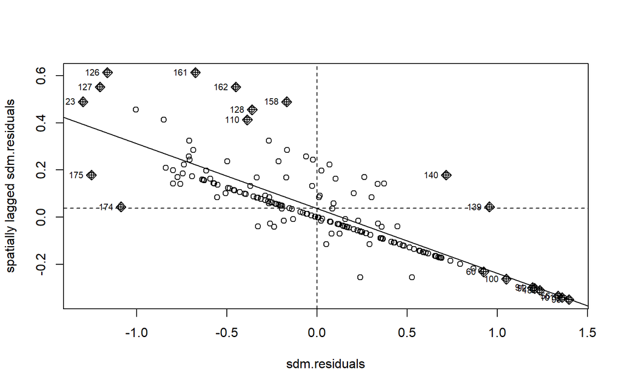

```r
sdm.residuals=sdm$residuals
moran.plot(sdm.residuals, w_knn2)
```

```r
#Robust SDM M_EStimator
robust.SDM=function(X,y,bobot,rho)
{
  n=length(y)
  k=ncol(X)
  bo=rep(1,n)
  X=cbind(bo,X)
  X=as.matrix(X)
  p=k+1
  c=4.685
  I=diag(rep(1,n))
  W=rho*bobot
  W=as.matrix(W)
  V=I-W
  yb=V%*%y

  #Step 1: Menghitung Nilai Delta
  delta_awal=solve(crossprod(X,X),tol=1e-20)%*%t(X)%*%yb
  cat("Nilai delta awal=\n")
  print(delta_awal)

  #Step 2: Menghitung Residual
  yhat=W%*%y+X%*%delta_awal
  residual=y-yhat

  #Step 3: Proses Iterasi
  s=median(abs(residual-median(residual)))/0.6745
  u=(residual/s)
  u_absolut=abs(u)
  w=rep(0,n)
  for(j in 1:n){
    if (u_absolut[j]>c) {w[j]=0}
    else {w[j]=(1-(u[j]/c)^2)^2}
  }
  Wr=diag(w,n)
  wjumlah=sum(diag(Wr))
  WX=Wr%*%X
  delta=solve(crossprod(X,WX),tol=1e-20)%*%t(X)%*%Wr%*%yb
  a=0
  #Iterasi Selanjutnya
  repeat{
    con=abs(delta-delta_awal)/abs(delta)
    if(con[1,]<=0.01 && con[2,]<=0.01 && con[3,]<=0.01 &&
       con[4,]<=0.01 && con[5,]<=0.01 && con[6,]<=0.01
       && con[7,]<=0.01 && con[8,]<=0.01 && con[9,]<=0.01 &&
       con[10,]<=0.01) {
      cat("\n")
      cat("\n")
      cat("====================ITERASI
SELESAI================\n")
      break}
    else {
      a=a+1
      cat("\n")
      cat("\n")
      cat("*********************ITERASI",a, "*********************\n")
      M<-matrix(c(residual,u_absolut,w),nrow=n)
      cat("\n--------------------------------------------\n")
      cat(" No residual |u| w")
      cat("\n--------------------------------------------\n")
      print(M)

      #Step 4: Menghitung Nilai Delta Iterasi Selanjutnya
      cat("...................................................\n")
      cat("Nilai delta=\n")
      print(delta)
      #Menghitung Nilai Prediksi dan Residual
      delta_awal=delta
      ytopi=W%*%y+X%*%delta_awal
      residual=y-ytopi

      s=median(abs(residual-median(residual)))/0.6745
      u=(residual/s)
      u_absolut=abs(u)
      w=rep(0,n)
      for(j in 1:n){
        if (u_absolut[j]>c) {w[j]=0}
        else {w[j]=(1-(u[j]/c)^2)^2}
      }
      Wr=diag(w,n)
      wjumlah=sum(diag(Wr))
      WX=Wr%*%X
      delta=solve(crossprod(X,WX),tol=1e-20)%*%t(X)%*%Wr%*%yb
    }
  }

  #Step 5: Menghitung MSE
  v=rep(0,n)
  for (i in 1:n) {
    if (w[i]==0) {v[i]=1}
    else {v[i]=0}
  }
  bobot_nol=sum(v)
  H=X%*%solve(crossprod(X,WX),tol=1e-20)%*%t(X)%*%Wr
  SSE=t(yb)%*%t(I-H)%*%Wr%*%(I-H)%*%yb
  db=n-k-1-bobot_nol
  MSE=SSE/db
  cat("...................................................\n")
  cat("MSE\n")
  print(MSE)

  #Step 6: Menghitung Rsquare
  SST=0
  wy=0
  for(i in 1:n){
    wy=wy+(w[i]*y[i])}
  ywbar=wy/wjumlah
  for(i in 1:n){
    SST=SST+(w[i]*(y[i]-ywbar)^2)
  }
  Rsquare=1-(SSE/SST)
  cat("...................................................\n")
  cat("Rsquare\n")
  print(Rsquare)

  #Step 7: Menghitung Adjusted Rsquare
  Adjusted_Rsquare=1-(((n-1)/(n-k-1))*(1-Rsquare))
  cat("...................................................\n")
  cat("Adjusted Rsquare\n")
  print(Adjusted_Rsquare)

  #Step 8: Uji Kecocokan Model
  SSR=SST-SSE
  MSR=SSR/k
  Fhit=MSR/MSE
  sig_F=1-pf(Fhit,k,db)
  F_hitung=cbind(Fhit,sig_F)
  colnames(F_hitung)=c("F_hit","sig")
  cat("...................................................\n")
  cat("F hitung\n")
  print(F_hitung)

  #Step 9: Uji Signifikansi Parameter
  Wy=bobot%*%y
  Z=cbind(Wy,X)
  WZ=Wr%*%Z
  var_delta=diag(solve(crossprod(Z,WZ),tol=1e-20))*MSE
  Zb=data.frame(rho,t(delta_awal))
  par=t(Zb)
  wald=par^2/var_delta
  sig_wald=1-pchisq(wald,1)
  wald_hitung=cbind(par,var_delta,wald,sig_wald)
  colnames(wald_hitung)=c("delta","var_delta","Wald","Sig.")
  cat("...................................................\n")
  cat("Wald hitung\n")
  print(wald_hitung)
  #Simpan Hasil
  return(list(Koefisien=par,Uji_Wald=wald_hitung,
              R.Square=Rsquare,Adj.RSq=Adjusted_Rsquare,
              Uji.F = F_hitung, MSE = MSE,
              Residuals=residual,Pred=y-residual))
}

y <- datafix[,6]
x <- datafix[,(7:16)]
bobot <- listw2mat(w_knn2)
lagX <- create_WX(x, w_knn2, prefix = "lag")

x_lag <- cbind(x, lagX)
```

```r
rsdm <- robust.SDM(x_lag, y, bobot, rho = 0.604461)
```

```
## Nilai delta awal=
##                  [,1]
## bo        0.009122103
## UMK       1.171899967
## TPAK     -0.184618260
## DR        0.102797051
## KP       -0.139861895
## PPM       0.055718347
## RLS      -1.206776793
## EG       -0.282689075
## AHH      -0.414500113
## PPS       0.061420387
## PMA      -0.023766536
## lag.UMK  -1.003615925
## lag.TPAK -0.092054980
```

[output cut: 1063 more lines]

```
## ...................................................
## Wald hitung
##                 delta    var_delta        Wald         Sig.
## rho       0.604461000 0.0043149114 84.67684797 0.000000e+00
## bo       -0.006636726 0.0008324034  0.05291441 8.180674e-01
## UMK       1.217044760 0.0438355261 33.78989781 6.139686e-09
## TPAK     -0.169554094 0.0026091977 11.01817279 9.022296e-04
## DR        0.091897681 0.0033927261  2.48920293 1.146298e-01
## KP       -0.146580816 0.0811455539  0.26478266 6.068533e-01
## PPM       0.026148975 0.0212986692  0.03210383 8.578000e-01
## RLS      -1.219353245 0.1535458063  9.68324940 1.859555e-03
## EG       -0.321372538 0.0017648344 58.52124732 2.009504e-14
## AHH      -0.441486938 0.2403698695  0.81087832 3.678607e-01
## PPS       0.049386277 0.0011768831  2.07242696 1.499827e-01
## PMA      -0.023454093 0.0009417859  0.58409717 4.447108e-01
## lag.UMK  -1.040888596 0.0468825788 23.10984370 1.530054e-06
## lag.TPAK -0.078312740 0.0056680812  1.08200378 2.982497e-01
## lag.DR   -0.073222486 0.0059893415  0.89517896 3.440777e-01
## lag.KP    0.375865870 0.0832529208  1.69693929 1.926887e-01
## lag.PPM   0.084345913 0.0223273355  0.31863332 5.724301e-01
## lag.RLS   1.034092249 0.1606463077  6.65652883 9.879317e-03
## lag.EG    0.078502469 0.0122248840  0.50410602 4.777015e-01
## lag.AHH   0.487133242 0.2409787305  0.98472921 3.210340e-01
## lag.PPS   0.102436255 0.0053807577  1.95013174 1.625727e-01
## lag.PMA   0.200476797 0.0049217703  8.16595324 4.268403e-03
```

```r
rsdm
```

```
## $Koefisien
##                  [,1]
## rho       0.604461000
## bo       -0.006636726
## UMK       1.217044760
## TPAK     -0.169554094
## DR        0.091897681
## KP       -0.146580816
## PPM       0.026148975
## RLS      -1.219353245
## EG       -0.321372538
## AHH      -0.441486938
## PPS       0.049386277
## PMA      -0.023454093
## lag.UMK  -1.040888596
```

[output cut: 406 more lines]

```r
#Normalitas sisaan
res <- rsdm$Residuals
ks.test(res, "pnorm", mean = mean(res), sd = sd(res))
```

```
##
##  Asymptotic one-sample Kolmogorov-Smirnov test
##
## data:  res
## D = 0.084646, p-value = 0.1628
## alternative hypothesis: two-sided
```

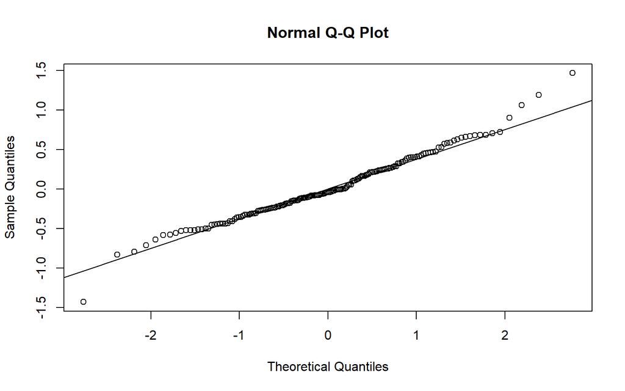

```r
qqnorm(res)
qqline(res)
```

```r
#Kehomogenan ragam
err <- abs(res)
datafix$err <- err
rsdm.glejser <- lm(err ~ UMK + TPAK + DR + KP + PPM + RLS + EG + AHH + PPS + PMA, data = datafix)
summary(rsdm.glejser)
```

```
##
## Call:
## lm(formula = err ~ UMK + TPAK + DR + KP + PPM + RLS + EG + AHH +
##     PPS + PMA, data = datafix)
##
## Residuals:
##      Min       1Q   Median       3Q      Max
## -0.44709 -0.17730 -0.03465  0.11165  1.14511
##
## Coefficients:
##              Estimate Std. Error t value Pr(>|t|)
## (Intercept)  0.311870   0.019027  16.391   <2e-16 ***
## UMK          0.037800   0.029637   1.275   0.2040
## TPAK         0.005743   0.023002   0.250   0.8032
## DR           0.054049   0.031783   1.701   0.0909 .
## KP           0.052196   0.044384   1.176   0.2413
## PPM          0.002980   0.031811   0.094   0.9255
## RLS          0.015594   0.047399   0.329   0.7426
## EG          -0.015068   0.019804  -0.761   0.4479
## AHH          0.006269   0.025168   0.249   0.8036
## PPS          0.008941   0.020646   0.433   0.6655
## PMA         -0.022663   0.020408  -1.110   0.2684
## ---
## Signif. codes:  0 '***' 0.001 '**' 0.01 '*' 0.05 '.' 0.1 ' ' 1
##
## Residual standard error: 0.2517 on 164 degrees of freedom
## Multiple R-squared:  0.06073,    Adjusted R-squared:  0.003462
## F-statistic:  1.06 on 10 and 164 DF,  p-value: 0.3958
```

```r
#Kebebasan sisaan
runs.test(res)
```

```
##
##  Runs Test
##
## data:  res
## statistic = -1.3685, runs = 79, n1 = 87, n2 = 87, n = 174, p-value =
## 0.1711
## alternative hypothesis: nonrandomness
```